# US Urban growth

Ruari Rhodes

# Multi-lingual spatial data workflows

## R, Python and Earth Engine

This document will walk you through some uses for an interactive R/Python script, with calls to the Earth Engine API embedded. It assumes working knowledge of all three languages, but should be straightforward to follow the majority of the process.

As an example, we will investigate the 20 largest urban areas by population in the USA. Urban area statistics are captured by the US census in “Census Statistical Areas” (CSA), which encompass conurbations.

As always, we will start by loading libraries:

```r
library( tidyverse)
library( sf)
library( here)
library( googledrive)
library( gridExtra)
library( reticulate)
use_python("/anaconda3/bin/python")
```

## Simple Features and spatial data in R

We start by loading in some Census Statistical Area (CSA) population data (originally pulled from Wikipedia). Our populations are stored in a CSV file, and we’ll be joining them onto a Simple Features dataframe of spatial polygons.

```r
( urban_areas <- read_csv( here( 'data_in', 'populous_urban_areas.csv')) %>%
    select( Rank, CSA, Pop = `2017 Estimate`) %>%
    mutate( CSA = gsub( " CSA", "", CSA)) )
```

| Rank | CSA | Pop |
| --- | --- | --- |
| 1 | New York-Newark, NY-NJ-CT-PA | 20320876 |
| 2 | Los Angeles-Long Beach, CA | 13353907 |
| 3 | Chicago-Naperville, IL-IN-WI | 9533040 |
| 4 | Dallas-Fort Worth, TX-OK | 7399662 |
| 5 | Houston-The Woodlands, TX | 6892427 |
| 6 | Washington-Baltimore-Arlington, DC-MD-VA-WV-PA | 6216589 |
| 7 | Miami-Fort Lauderdale-Port St. Lucie, FL | 6158824 |
| 8 | Philadelphia-Reading-Camden, PA-NJ-DE-MD | 6096120 |
| 9 | Atlanta-Athens-Sandy Springs, GA | 5884736 |
| 10 | Boston-Worcester-Providence, MA-RI-NH-CT | 4836531 |

[output cut: 373 more lines]

Now we have our population data for each CSA, we can join them to a spatial polygon database (a “Simple Feature”) (freely available from the US Gov’t TIGER shapefile database:

```r
csa <- read_sf( here( 'data_in', 'cb_2017_us_csa_500k', 'cb_2017_us_csa_500k.shp'))
```

csa is a “SimpleFeatures” object. This is a normal dataframe with a geometry column attached; in this case the geometry is a polygon demarcating the boundaries of each region.

Let’s investigate the data inside csa:

```r
head( csa)
```

| CSAFP | AFFGEOID | GEOID | NAME | LSAD | ALAND | AWATER | geometry |
| --- | --- | --- | --- | --- | --- | --- | --- |
| 450 | 330M300US450 | 450 | Raleigh-Durham-Chapel Hill, NC | M0 | 14270829773 | 301833048 |  |
| 544 | 330M300US544 | 544 | Victoria-Port Lavaca, TX | M0 | 5804050524 | 1398360729 |  |
| 324 | 330M300US324 | 324 | Lake Charles-Jennings, LA | M0 | 7771400431 | 1784449473 |  |
| 548 | 330M300US548 | 548 | Washington-Baltimore-Arlington, DC-MD-VA-WV-PA | M0 | 32712037570 | 5208979324 |  |
| 268 | 330M300US268 | 268 | Greensboro--Winston-Salem--High Point, NC | M0 | 12845012068 | 188816451 |  |
| 533 | 330M300US533 | 533 | Tallahassee-Bainbridge, FL-GA | M0 | 7730744155 | 623910157 |  |

We can see that NAME contains the standard format CSA name as we have in the population dataset, meaning we can join the two using inner_join(). We’ll also filter the data to the 20 most populous regions.

```r
# How many CSAs to keep?
n_csa <- 20


(csa_filtered <- csa %>%
    inner_join( urban_areas, by=c("NAME" = "CSA")) %>%
    arrange( desc(Pop)) %>%
    head(    n_csa) %>%
    select(  NAME, Pop) )
```

| NAME | Pop | geometry |
| --- | --- | --- |
| New York-Newark, NY-NJ-CT-PA | 20320876 |  |
| Los Angeles-Long Beach, CA | 13353907 |  |
| Chicago-Naperville, IL-IN-WI | 9533040 |  |
| Dallas-Fort Worth, TX-OK | 7399662 |  |
| Houston-The Woodlands, TX | 6892427 |  |
| Washington-Baltimore-Arlington, DC-MD-VA-WV-PA | 6216589 |  |
| Miami-Fort Lauderdale-Port St. Lucie, FL | 6158824 |  |
| Philadelphia-Reading-Camden, PA-NJ-DE-MD | 6096120 |  |
| Boston-Worcester-Providence, MA-RI-NH-CT | 4836531 |  |
| San Jose-San Francisco-Oakland, CA | 4727357 |  |

[output cut: 10 more lines]

## Visualising in R

So, where are these regions?

*R top tip:* ggplot + geom_sf() will plot **sf** objects within the grammar of graphics framework (i.e. in a simple, readable, layerable way)

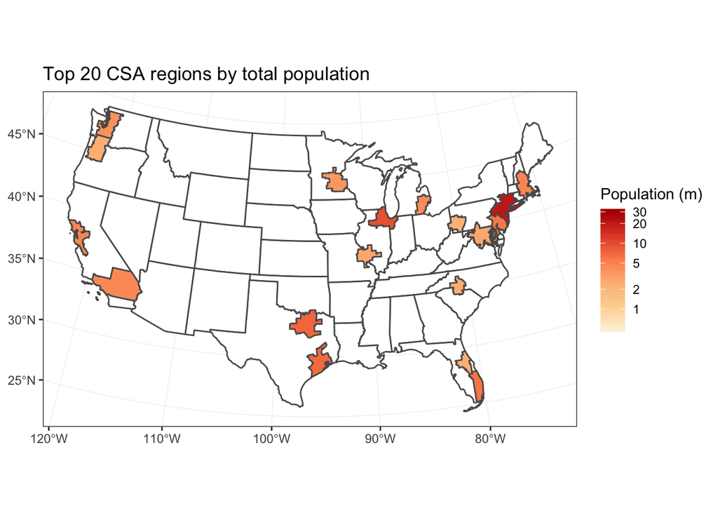

```r
# Load a state shapefile, and filter out states (and territories) that aren't in the lower 48
states_sf <- read_sf( here( 'data_in/cb_2017_us_state_20m/cb_2017_us_state_20m.shp')) %>%
  filter( !(STUSPS %in% c( "AK", "HI", "PR")))

# Plot a map of the USA. Overlay CSA regions coloured by population.
ggplot(csa_filtered) +
  geom_sf(data = states_sf, fill = "white") +
  geom_sf(aes(fill = Pop / 1e6)) +
  coord_sf(crs = 5070) +
  scale_fill_distiller(
    "Population (m)",
    palette = "OrRd",
    labels = scales::comma,
    direction = 1,
    trans  = "log10",
    limits = c(0.5, 30),
    breaks = c( 1, 2, 5, 10, 20, 30)
  ) +
  theme_bw() +
  ggtitle( sprintf( "Top %i CSA regions by total population", n_csa))
```

## Transfer to Python

So we’ve got the top 20 census urban regions by population. But R isn’t going to be powerful enough to analyse land use changes for these regions, so it’s time to bring in Earth Engine.

We can use R to create a plaintext version of an Earth Engine geometry, which can be passed to Python to use its Earth Engine API.

We can either write this plaintext to a file to re-import to the Python interpreter, or we can pass it directly to python using the “r.data” structure

```r
csa_filtered %>%
  split( .$NAME) %>%
  walk( function(x){
    if( nrow(x) > 1){ ## If a CSA is multipolygon, take the poly with the highest population
                      ## (This is a bit of a hack and should be fixed with st_union)
      x <- x %>% slice( which( .$Pop == max( .$Pop)))
    }
    coord_mat <- x %>% st_coordinates() %>% .[,c("X","Y")] %>% t()
    coord_out <- coord_mat %>% as.vector() %>% paste( collapse=" ")
    #coord_out <- paste( "[", coord_out, "]")
    filename <- paste0( x$NAME, ".txt")
    write_lines( coord_out, here('data_out', 'csa_wkt', filename))
  })
```

Here we have output everything to text files for future reference, but note that we could simply have transferred data from an R chunk to a Python chunk. For example, if we create a dataframe in R called test data:

```r
test_data <- data.frame( a=1:10, b=11:20)
```

We can access it in Python using r.test_data:

```python
test_data = r.test_data
test_data.describe()
```

And we can send it back to R again as py$test_data

```r
py$test_data %>% glimpse()
```

```
## Observations: 10
## Variables: 2
## $ a <int> 1, 2, 3, 4, 5, 6, 7, 8, 9, 10
## $ b <int> 11, 12, 13, 14, 15, 16, 17, 18, 19, 20
```